# What have we done?

Quick overview for the other students:

### Exploratory Analysis

This is what the data looked like before cleaning:

```python
import pandas as pd
from sklearn.model_selection import train_test_split
from sklearn import model_selection, linear_model, neighbors, preprocessing, metrics, model_selection, impute
import numpy as np
import matplotlib.pyplot as plt
import seaborn as sns
import matplotlib.style as style
```

```python
RhoMis = pd.read_csv("data/RHoMIS_Indicators.csv", engine ="python")

RhoMis_full = pd.read_csv("data/RHoMIS_Full_Data.csv", engine ="python")
full = RhoMis_full

data = RhoMis
data.head()
```

|  | ID_PROJ | ID_COUNTRY | YEAR | ITERATION | SURVEY_ID | ID_HH | GPS_LAT | GPS_LON | GPS_ALT | Country | ... | value_livestock_prod_consumed_USD_PPP_pHH_Yr | Market_Orientation | Livestock_Orientation | Food_Availability_kCal_MAE_day | Food_Self_Sufficiency_kCal_MAE_day | NrofMonthsWildFoodCons | GHGEmissions | Gender_MaleControl | Gender_FemaleControl | NFertInput |
| --- | --- | --- | --- | --- | --- | --- | --- | --- | --- | --- | --- | --- | --- | --- | --- | --- | --- | --- | --- | --- | --- |
| 0 | CFM | TZ | 2015 | 1 | TZ_CFM_2015 | TZ_2015_CFM_1_1 | NaN | NaN | NaN | Tanzania | ... | 0.000000 | 1.000000 | 0.049505 | 3650.565755 | 0.000000 | 0 | NaN | 0.000000 | 1.000000 | NaN |
| 1 | CFM | TZ | 2015 | 1 | TZ_CFM_2015 | TZ_2015_CFM_2_1 | NaN | NaN | NaN | Tanzania | ... | 0.000000 | 1.000000 | 0.000000 | 3632.448997 | 0.000000 | 4 | 143.934000 | 0.499999 | 0.500001 | 75.0 |
| 2 | CFM | TZ | 2015 | 1 | TZ_CFM_2015 | TZ_2015_CFM_3_1 | NaN | NaN | NaN | Tanzania | ... | 0.000000 | 1.000000 | 0.129870 | 5314.779021 | 1750.000000 | 1 | 3248.700905 | 1.000000 | 0.000000 | 20.0 |
| 3 | CFM | TZ | 2015 | 1 | TZ_CFM_2015 | TZ_2015_CFM_4_1 | NaN | NaN | NaN | Tanzania | ... | 0.000000 | NaN | NaN | 257.234727 | 257.234727 | 0 | 887.156057 | NaN | NaN | 15.0 |
| 4 | CFM | TZ | 2015 | 1 | TZ_CFM_2015 | TZ_2015_CFM_5_1 | NaN | NaN | NaN | Tanzania | ... | 23.102694 | 0.931377 | 0.695041 | 925.310354 | 22.070240 | 0 | 14275.030776 | 1.000000 | 0.000000 | 50.0 |

5 rows × 53 columns

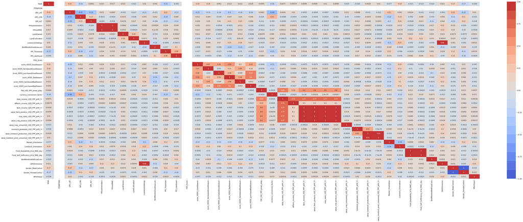

```python
#Correlation Heat Map, ALL Variables only numerical variables here
numerics  = data.select_dtypes(include=['int64', "float64"])
corr = numerics.corr()

plt.figure(figsize=(60, 20))
sns.heatmap(corr, cmap=sns.color_palette("coolwarm", 20), annot=True);
```

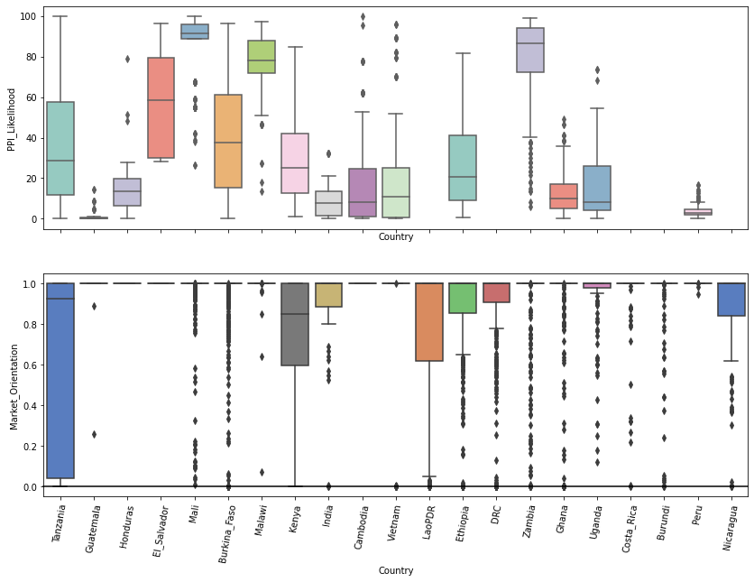

```python
f, (ax1, ax2) = plt.subplots(2, 1, figsize=(14, 10),
                             sharex=True)

#PPI_ Likelihood
sns.boxplot(x="Country",
                  y='PPI_Likelihood',
                  data = data,
                  palette="Set3", ax=ax1)


# Market Orientation
sns.boxplot(x="Country",
            y="Market_Orientation",
            data=data,
            palette="muted",
            ax=ax2)

ax2.axhline(0, color="k",
            clip_on=False)


ax2.set_xticklabels(ax2.get_xticklabels(),
                    rotation=80)

plt.figure(figsize=(20, 10))
```

### Data Cleaning

Why did we choose the variables we did?

- redundant with a summary statistic?
- appropriate number of NAs
- relevant to our question
- the process was kind of by hand

Full data shape: (13310, 758) "Clean" data shape: (13310, 46)

### function/general reproducibility approaches

Approaches:

- Imputations
- Convert to Categories

```python
class Functions:
    """
     Conatins all cleaning function for this data
    """

#     def __init__(self,df):

    def getNAs(self, df):
        colNames = []
        percentNA = []
        for i in df.columns:
            colNames.append(i)
            numNA = df[i].isna().sum()
            percent = (numNA/len(df))*100
            percentNA.append(percent)

        colNames = pd.DataFrame(colNames)
        colNames = colNames.rename(columns={0: "label"})
        percentNA = pd.DataFrame(percentNA)
        percentNA = percentNA.rename(columns={0: "numNA"})
        self.data = pd.concat([colNames,percentNA], axis = 1).sort_values(by=['numNA'], ascending = False)

        return self.data

    def drop_columns(self, df, threshold_percent):
        '''drop columns by a threshold (percentage of na)'''
        global data ### double check...
        data = self.getNAs(df)
        column_names = data[data.numNA >= threshold_percent].label
        self.clean_data = df.drop(column_names, axis = 1)

        return self.clean_data

    def entry_to_lowercase(self, df):
        for i in df.columns:
            if (df[i].dtype == "O"):
                df[i] = df[i].str.lower()
        return df

    def id_data_types(self, df):
        names = pd.DataFrame()
        category = pd.DataFrame()
        data_type = pd.DataFrame()
        numUni = pd.DataFrame()

        for i in df.columns:

            names = names.append({"variable": i},ignore_index = True)
            category = category.append({"category": list(df[i].unique())}, ignore_index = True)
            numUni = numUni.append({"numUnique": len(df[i].unique())}, ignore_index = True)
            data_type = data_type.append({"data_type": df[i].dtype}, ignore_index = True)

        view_data = pd.concat([names, category, numUni,data_type],axis =1)

        return (view_data)

    def replace_na_with_NaN(self, df):

        """
         Input: Full dataset
         Output: Full dataset where object strings have underscores and spaces removed
         EX:'No_School-> NoSchool, no school -> noschool'
        """

        for i in df.columns:
            df[i] = df[i].replace(np.nan, 'na')
        return df

    # removes underscores and spaces from instances,
    def remove_underscores_spaces(self, df):

        """
         Input: Full dataset
         Output: Full dataset where object strings have underscores and spaces removed
         EX:'No_School-> NoSchool, no school -> noschool'
        """

        for i in df.columns:
            if (df[i].dtype == "O"):
                df[i] = df[i].str.replace('_', "")
                df[i] = df[i].str.replace(' ', "")
        return df



    def convert_to_categorical(self, df, variables):
        """
         Input: dataframe, column names of variables to be transformed
         Output: dataframe with dtypes of indicated variables changed

         #NOTE: USE this function AFTER preprocessing functions above
        """

    # convert these to categories
    #df[v1] = df[v1].astype(‘category’)

        for i in variables:
            df[i] = df[i].astype('category')
        return df


    def impute_data(self, Xtrain, Xtest):
        """
        Input: XTraining set, XTesting Set
        Output: The inputs with NA numerical variabes imputed by column median, and categorical
        NA varaibles converted into a seperate category "Na"
        """



        num_train = Xtrain.select_dtypes(include=['float64', 'int64'])
        num_test = Xtest.select_dtypes(include=['float64', 'int64'])

        cat_train = Xtrain.select_dtypes(include=['object', 'category'])
        cat_test = Xtest.select_dtypes(include=['object', 'category'])


    # imputes NA numerics with median
        for i in num_train.columns:
            Xtrain[i] = num_train.fillna(np.nanmedian(Xtrain[i]))

        for i in num_test.columns:
            Xtest[i] = num_test.fillna(np.nanmedian(num_test[i]))

    # categorical NA to "Na" level
        for i in cat_train.columns:
            Xtrain[i] = cat_train.replace(np.nan, "Na")

        for i in cat_test.columns:
            Xtest[i] = cat_test.replace(np.nan, "Na")


        return Xtrain, Xtest

    def drop_response_rows_with_NAs(self,df,y_variable):
        """
        Input: dataframe, response variable column
        Output: dataframe rows with missing response varaibles
        are dropped entirely (we cannot use these to train or test)
        But these dropped rows are saved to be used later

        """

    ## need to delete PPI_threshold since that is like our y2 which we won’t use
        df = df.drop("PPI_Threshold", axis=1)
        condition = df[y_variable]
        rows_to_delete = df[np.isnan(condition)].index

    #save all rows with y=NA. Will use this data to predict the y later.
        prediction_dataset = df.iloc[rows_to_delete,:]

    #create new data
        new_data = df.drop(labels=rows_to_delete, axis=0)

        return new_data, prediction_dataset
```

### Models!

OLS

Ridge

- How do you know which coefficient corresponds to each variable?

LASSO/Group LASSO

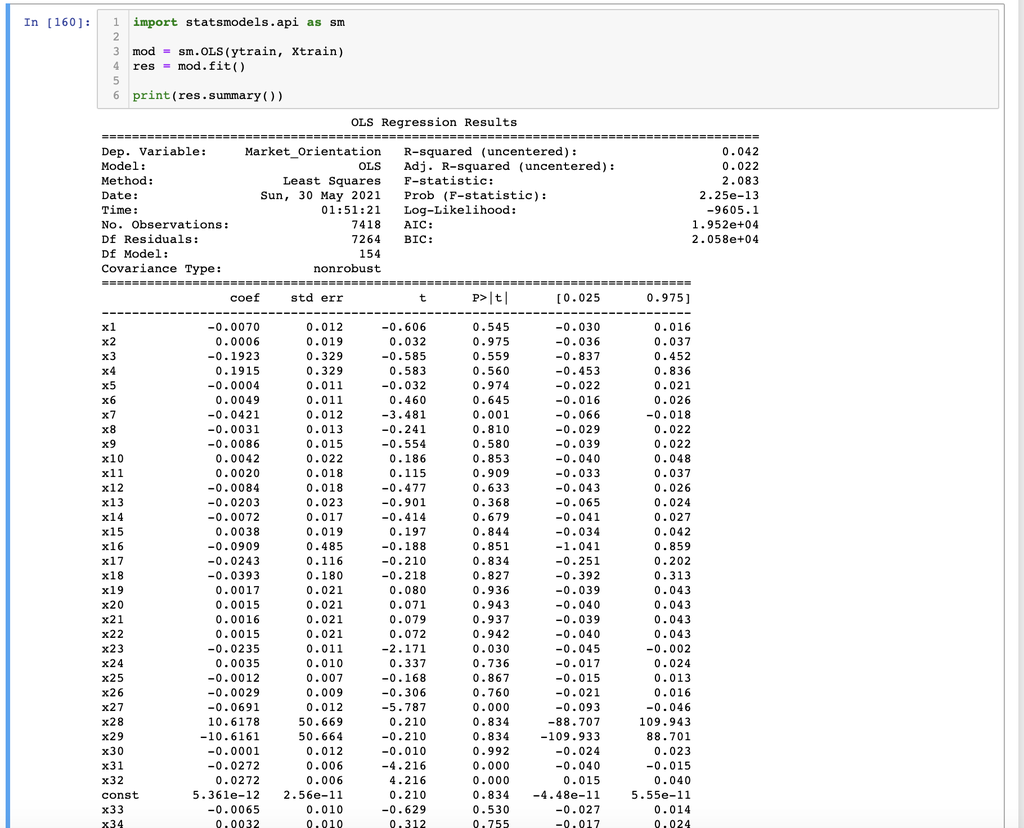

```python
from IPython.display import Image
Image("/Users/maryfrancis/Desktop/Market_full.png")
```

#### Ridge Regression MSE values

PPI MSE: 444.7761019609122

Market Orientation MSE: 0.48637505548690013 **Go to File to see coefficient problem**

### LASSO/Group LASSO

**Go to File to talk about the in-progress results + minimal interpretation**

# What do we want to do next?

- Which model performs the best?
- Get specific coefficients and fit the model with those, on the predict dataset

# Questions we have:

- What are our variables? Is the analysis chronological (x1 = column 1)? How do we interpret?
- We spent so much time on data cleaning-- what should we focus on in the time we have left?

### What are we clearly missing?